# Simulation Modeling: Applications in Cropping Systems - ScienceDirect

[figure not shown]

## Cited By (13)

## Figures (4)

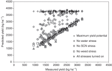

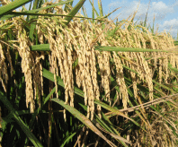

[figure not shown]

[Reference Module in Food Science](https://www.sciencedirect.com/science/referenceworks/9780081005965)

## [Encyclopedia of Agriculture and Food Systems](https://www.sciencedirect.com/science/referenceworks/9780080931395)

2014, Pages 102-112

# Simulation Modeling: Applications in Cropping Systems

[S.Asseng](https://www.sciencedirect.com/science/article/pii/B9780444525123002333#!)[Y.Zhu](https://www.sciencedirect.com/science/article/pii/B9780444525123002333#!)[B.Basso](https://www.sciencedirect.com/science/article/pii/B9780444525123002333#!)[T.Wilson](https://www.sciencedirect.com/science/article/pii/B9780444525123002333#!)[D.Cammarano](https://www.sciencedirect.com/science/article/pii/B9780444525123002333#!)

## Abstract

Crop models are a formal way to present quantitative knowledge about how a crop grows in interaction with its environment. Using weather data and other data about the crop environment, these models can simulate crop development, growth, yield, water, and nutrient uptake. The data used in crop models include daily weather data, such as solar radiation, maximum and minimum temperatures, rainfall, as well as soil characteristics, initial soil conditions, cultivar characteristics, and crop management. Crop models are mathematical algorithms that capture the quantitative information of agronomy and physiology experiments in a way that can explain and predict crop growth and development. They can simulate many seasons, locations, treatments, and scenarios in a few minutes. Crop models contribute to agriculture in many ways. They help explore the dynamics between the atmosphere, the crop, and the soil, assist in crop agronomy, pest management, breeding, and natural resource management, and assess the impact of climate change.

## Keywords

Climate change impact

Crop development

Crop growth

Crop models

Cropping systems

Simulation experiments

Spatial variability

Yields

### Measuring and modelling crop yield losses due to invasive insect pests under climate change

- 2022, Current Opinion in Insect Science

### Seasonal crop yield forecast: Methods, applications, and accuracies

- 2019, Advances in Agronomy

  Citation Excerpt :

  The forecasted yield was modeled with trend-analysis forecast yield, the NDVI extracted from the IRS LISS-II images during the wheat heading to flowering stages, and temperature difference during vegetative phase. Process-based crop models use weather, soil, crop, and management information as input to simulate plant development and growth (Asseng et al., 2014; Basso et al., 2016). Aboveground biomass and grain yield are output variables of crop simulation models.

### Calibration and validation of APSIM-Wheat and CERES-Wheat for spring wheat under rainfed conditions: Models evaluation and application

- 2016, Computers and Electronics in Agriculture

  Citation Excerpt :

  Various models have been developed primarily to understand yield gaps and to optimize yield potential. These include APES (Donatelli et al., 2002), APSIM (Keating et al., 2003), CERES (Ritchie et al., 1998), CROPGRO (Godwin and Singh, 1998), CropSyst (Rosenzweig and Parry, 1994; Willmott et al., 1985), DAISY (Sayre et al., 1997), DSSAT (Basso et al., 2016; Jones et al., 2003), EPIC (Wang et al., 2012), FASSET (Bassu et al., 2009), HERMES (Asseng et al., 2014), RZWQM (Ma et al., 2011), SPASS (Wang and Engel, 2000, 2002), STICS (Brisson et al., 2003), SWAP (Chen et al., 2010; Eitzinger et al., 2004; Ma et al., 2015), SOYGRO (Monsi and Saeki, 2005) and WOFOST (Eitzinger et al., 2004). An important task in experimenting with models is the testing of their performance in a wide range of circumstances to identify their scope of validity and limitations.

### Grand challenges for the 21st century: What crop models can and can't (yet) do

- 2020, Journal of Agricultural Science

### A Parsimonious Bayesian Crop Modeling Framework Based on Ordinary Differential Equations

- 2022, SSRN

### Costs and effectiveness of climate change adaptation in agriculture: a systematic review from the NENA region

- 2022, Climate Policy

[figure not shown]

[figure not shown]